# USP654 Lab 9: Variable Selection; DID regression

11/20/2017

We will be using the taxlot_sample and uber data for this lab. Download taxlot_sample.csv and uber DUI data

## Variable Selection

This section is adapted from [olsrr tutorial of variable selection](http://www.rsquaredacademy.com/olsrr/articles/variable_selection.html).

```r
require(tidyverse)
taxlot_sample <- read_csv("data/taxlot_sample.csv")

# create a subset with only single family residence
taxlot_sfr <- taxlot_sample %>%
  filter(sfr == 1)
```

### All possible subset

All subset regression tests all possible subsets of the set of potential independent variables. If there are K potential independent variables (besides the constant), then there are $2^k$ distinct subsets of them to be tested.

```r
if (!require(olsrr)) {
  install.packages("olsrr"); library(olsrr)
}

sfrmodel <- lm(TOTALVAL ~ BLDGSQFT + YEARBUILT + GIS_ACRES + dpioneer + dfwy + dpark + dmax + dbikehq, data = taxlot_sfr)

(sfrmodel_all_subset <- ols_all_subset(sfrmodel))
```

```
## # A tibble: 255 x 6
##    Index     N         Predictors `R-Square` `Adj. R-Square` `Mallow's Cp`
##    <int> <int>              <chr>      <chr>           <chr>         <chr>
##  1     1     1           BLDGSQFT    0.54149         0.54103     870.02214
##  2     2     1           dpioneer    0.28652         0.28581    1907.70119
##  3     3     1          GIS_ACRES    0.07168         0.07075    2782.03875
##  4     4     1          YEARBUILT    0.02638         0.02540    2966.41127
##  5     5     1               dfwy    0.01297         0.01198    3020.97363
##  6     6     1            dbikehq    0.00715         0.00615    3044.68719
##  7     7     1              dpark    0.00321         0.00221    3060.71980
##  8     8     1               dmax    0.00062        -0.00038    3071.25799
##  9     9     2  BLDGSQFT dpioneer    0.72394         0.72338     129.51151
## 10    10     2 BLDGSQFT YEARBUILT    0.60983         0.60905     593.89982
## # ... with 245 more rows
```

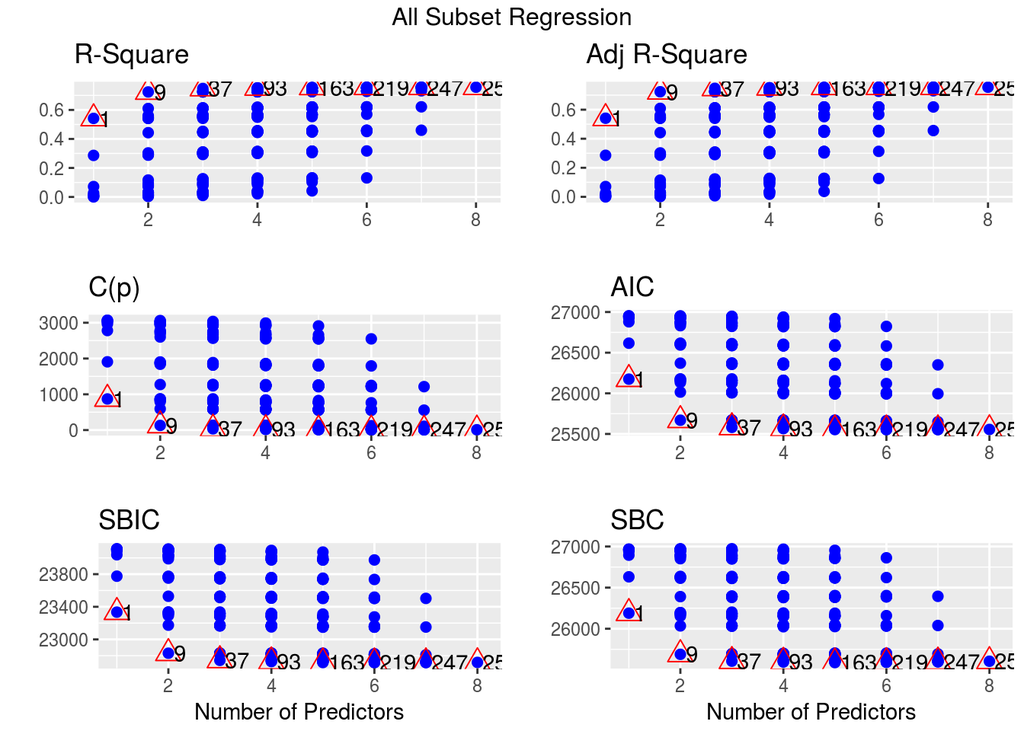

```r
plot(sfrmodel_all_subset)
```

### Best Subset Regression

Select the subset of predictors that do the best at meeting some well-defined objective criterion, such as having the largest R2 value or the smallest MSE, AIC, etc.

```r
(sfrmodel_best_subset <- ols_best_subset(sfrmodel))
```

```
##                           Best Subsets Regression
## ----------------------------------------------------------------------------
## Model Index    Predictors
## ----------------------------------------------------------------------------
##      1         BLDGSQFT
##      2         BLDGSQFT dpioneer
##      3         BLDGSQFT GIS_ACRES dpioneer
##      4         BLDGSQFT GIS_ACRES dpioneer dfwy
##      5         BLDGSQFT YEARBUILT GIS_ACRES dpioneer dfwy
##      6         BLDGSQFT YEARBUILT GIS_ACRES dpioneer dfwy dbikehq
##      7         BLDGSQFT YEARBUILT GIS_ACRES dpioneer dfwy dmax dbikehq
##      8         BLDGSQFT YEARBUILT GIS_ACRES dpioneer dfwy dpark dmax dbikehq
## ----------------------------------------------------------------------------
##
##                                                                     Subsets Regression Summary
## ------------------------------------------------------------------------------------------------------------------------------------------------------------------
##                        Adj.        Pred
## Model    R-Square    R-Square    R-Square      C(p)         AIC           SBIC          SBC              MSEP                FPE                HSP          APC
## ------------------------------------------------------------------------------------------------------------------------------------------------------------------
##   1        0.5415      0.5410      0.5371    870.0221    26174.2989    23334.1347    26189.0222    13614835241.7223    13614780727.7583    13628490.9897    0.4603
##   2        0.7239      0.7234      0.7199    129.5115    25668.9490    22830.3882    25688.5800     8213803819.6139     8213721599.1908     8222042.3060    0.2777
##   3        0.7477      0.7469      0.7416     34.8405    25580.9765    22742.8890    25605.5153     7522147592.6669     7522012058.2047     7529692.3444    0.2543
##   4        0.7518      0.7508      0.7455     19.9437    25566.3845    22728.4088    25595.8310     7413255735.3920     7413047956.0365     7420691.2680    0.2507
##   5        0.7554      0.7542      0.7482      7.3842    25553.8635    22716.0420    25588.2178     7321101243.8573     7320808106.0835     7328444.3451    0.2475
##   6        0.7561      0.7546      0.7485      6.7782    25553.2420    22715.4666    25592.5040     7316655731.0949     7316260235.3987     7323994.3735    0.2474
##   7        0.7563      0.7546      0.7483      7.7823    25554.2383    22716.4937    25598.4081     7324067218.0803     7323554019.1497     7331413.2942    0.2476
##   8        0.7565      0.7545      0.7479      9.0000    25555.4492    22717.7354    25604.5268     7333074593.7015     7332428635.8875     7340429.7043    0.2479
## ------------------------------------------------------------------------------------------------------------------------------------------------------------------
## AIC: Akaike Information Criteria
##  SBIC: Sawa's Bayesian Information Criteria
##  SBC: Schwarz Bayesian Criteria
##  MSEP: Estimated error of prediction, assuming multivariate normality
##  FPE: Final Prediction Error
##  HSP: Hocking's Sp
##  APC: Amemiya Prediction Criteria
```

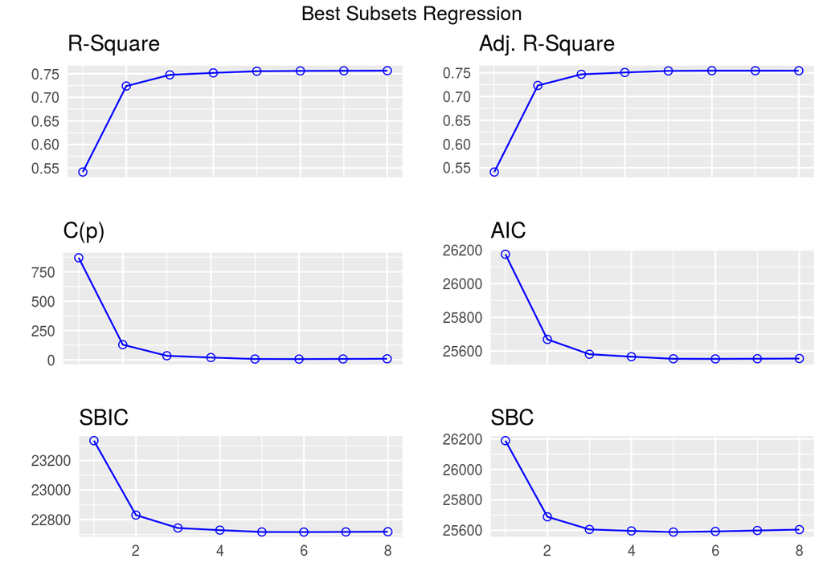

```r
plot(sfrmodel_best_subset)
```

### Stepwise Forward Regression

Build regression model from a set of candidate predictor variables by entering predictors in a stepwise manner until there is no variable left to enter any more.

```r
# Here . tells lm to use all variables except for the dependent variable
sfrmodel <- lm(TOTALVAL ~ BLDGSQFT + YEARBUILT + GIS_ACRES + dpioneer + dfwy + dpark + dmax + dbikehq, data = taxlot_sfr)

# based on p-value
(sfrmodel_stepfwd.p <- ols_step_forward(sfrmodel))
```

```
## Forward Selection Method
##
## Candidate Terms:
##
## 1 . BLDGSQFT
## 2 . YEARBUILT
## 3 . GIS_ACRES
## 4 . dpioneer
## 5 . dfwy
## 6 . dpark
## 7 . dmax
## 8 . dbikehq
##
## ----------------------------------------------------------------------------------
##                                 Selection Summary
## ----------------------------------------------------------------------------------
##         Variable                   Adj.
## Step     Entered     R-Square    R-Square      C(p)         AIC           RMSE
## ----------------------------------------------------------------------------------
##    1    BLDGSQFT       0.5415      0.5410    870.0221    26174.2989    116565.8849
##    2    dpioneer       0.7239      0.7234    129.5115    25668.9490     90493.9453
##    3    GIS_ACRES      0.7477      0.7469     34.8405    25580.9765     86556.5935
##    4    dfwy           0.7518      0.7508     19.9437    25566.3845     85884.6152
##    5    YEARBUILT      0.7554      0.7542      7.3842    25553.8635     85306.1852
##    6    dbikehq        0.7561      0.7546      6.7782    25553.2420     85237.3300
## ----------------------------------------------------------------------------------
```

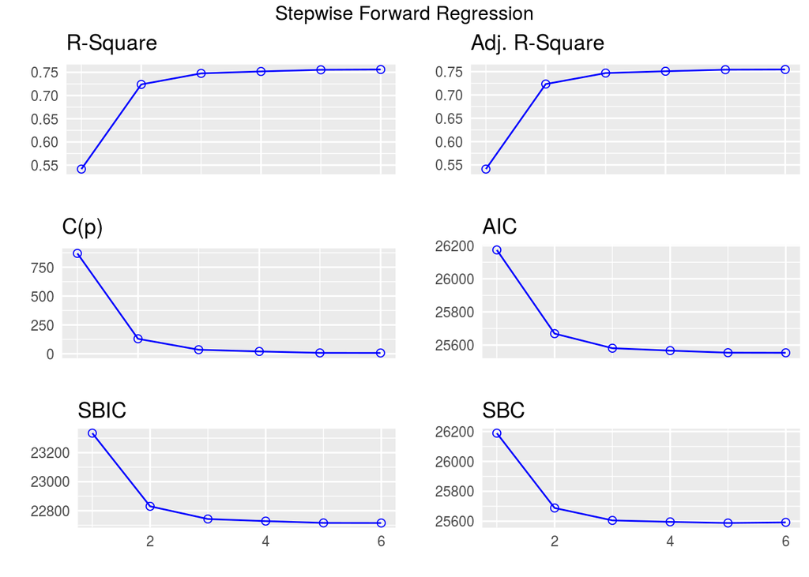

```r
plot(sfrmodel_stepfwd.p)
```

```r
# based on AIC
(sfrmodel_stepfwd.aic <- ols_stepaic_forward(sfrmodel))
```

```
## ----------------------------------------------------------------------------
## Variable        AIC          Sum Sq           RSS         R-Sq     Adj. R-Sq
## ----------------------------------------------------------------------------
## BLDGSQFT     26174.299    1.601471e+13    1.356043e+13    0.541        0.541
## dpioneer     25668.949    2.141055e+13    8.164587e+12    0.724        0.723
## GIS_ACRES    25580.977    2.211306e+13    7.462076e+12    0.748        0.747
## dfwy         25566.385    2.223585e+13    7.339286e+12    0.752        0.751
## YEARBUILT    25553.863    2.234166e+13    7.233482e+12    0.755        0.754
## dbikehq      25553.242    2.236059e+13    7.214545e+12    0.756        0.755
## ----------------------------------------------------------------------------
```

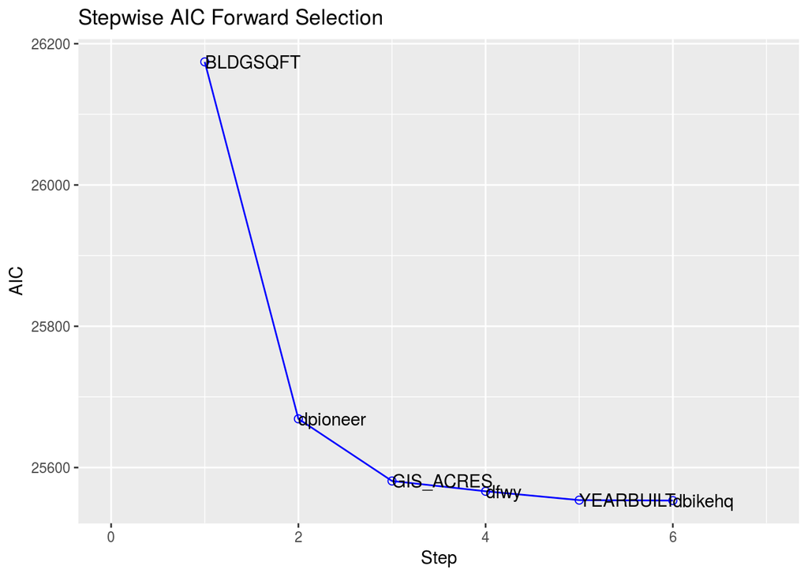

```r
plot(sfrmodel_stepfwd.aic)
```

### Stepwise Backward Regression

Build regression model from a set of candidate predictor variables by removing predictors in a stepwise manner until there is no variable left to remove any more.

```r
# based on p-value
(sfrmodel_stepbwd.p <- ols_step_backward(sfrmodel))
```

```
## Backward Elimination Method
##
## Candidate Terms:
##
## 1 . BLDGSQFT
## 2 . YEARBUILT
## 3 . GIS_ACRES
## 4 . dpioneer
## 5 . dfwy
## 6 . dpark
## 7 . dmax
## 8 . dbikehq
##
## ------------------------------------------------------------------------------
##                              Elimination Summary
## ------------------------------------------------------------------------------
##         Variable                  Adj.
## Step    Removed     R-Square    R-Square     C(p)        AIC           RMSE
## ------------------------------------------------------------------------------
##    1    dpark         0.7563      0.7546    7.7823    25554.2383    85237.4951
##    2    dmax          0.7561      0.7546    6.7782    25553.2420    85237.3300
## ------------------------------------------------------------------------------
```

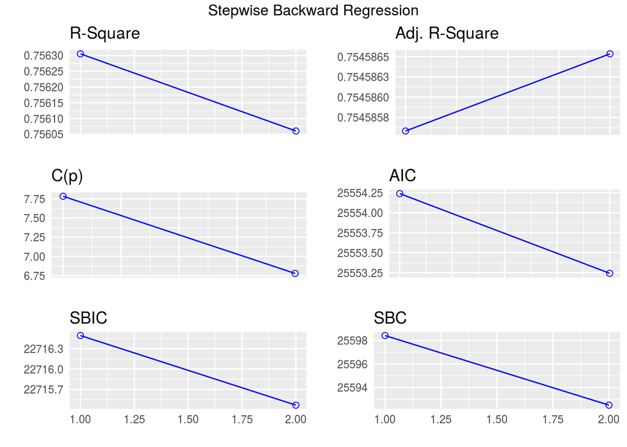

```r
plot(sfrmodel_stepbwd.p)
```

```r
# based on AIC
(sfrmodel_stepbwd.aic <- ols_stepaic_backward(sfrmodel))
```

```
##
##
##                          Backward Elimination Summary
## -----------------------------------------------------------------------------
## Variable         AIC           RSS            Sum Sq       R-Sq     Adj. R-Sq
## -----------------------------------------------------------------------------
## Full Model    25555.449    7.201622e+12    2.237352e+13    0.756        0.755
## dpark         25554.238    7.207307e+12    2.236783e+13    0.756        0.755
## dmax          25553.242    7.214545e+12    2.236059e+13    0.756        0.755
## -----------------------------------------------------------------------------
```

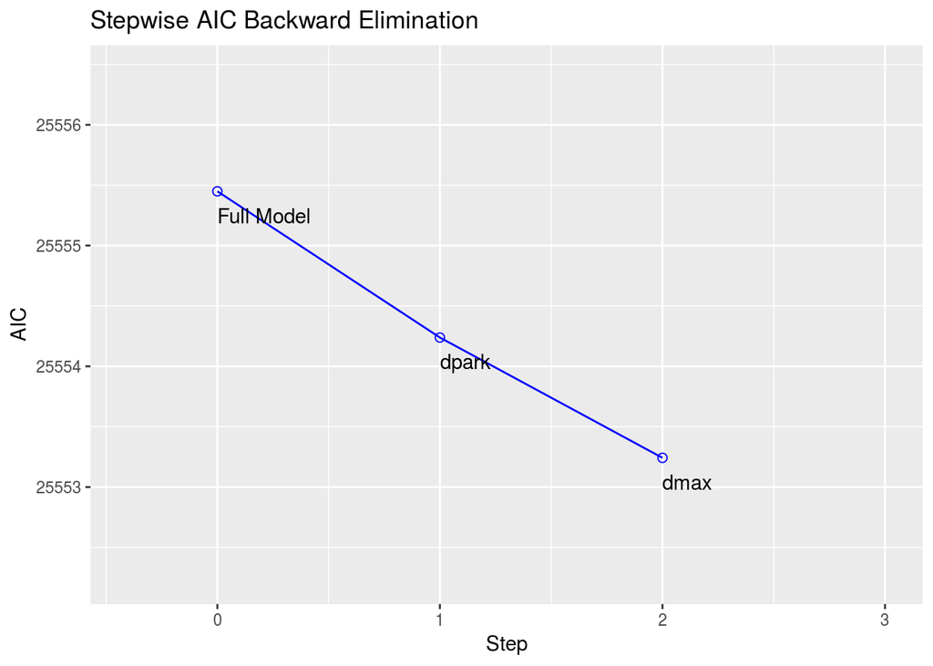

```r
plot(sfrmodel_stepbwd.aic)
```

### Step AIC regression

Build regression model from a set of candidate predictor variables by entering and removing predictors based on Akaike Information Criteria, in a stepwise manner until there is no variable left to enter or remove any more. The model should include all the candidate predictor variables.

```r
(sfrmodel_stepboth.aic <- ols_stepaic_both(sfrmodel))
```

```
##
##
##                                      Stepwise Summary
## ----------------------------------------------------------------------------------------
## Variable      Method        AIC           RSS            Sum Sq       R-Sq     Adj. R-Sq
## ----------------------------------------------------------------------------------------
## BLDGSQFT     addition    26174.299    1.356043e+13    1.601471e+13    0.541        0.541
## dpioneer     addition    25668.949    8.164587e+12    2.141055e+13    0.724        0.723
## GIS_ACRES    addition    25580.977    7.462076e+12    2.211306e+13    0.748        0.747
## dfwy         addition    25566.385    7.339286e+12    2.223585e+13    0.752        0.751
## YEARBUILT    addition    25553.863    7.233482e+12    2.234166e+13    0.755        0.754
## dbikehq      addition    25553.242    7.214545e+12    2.236059e+13    0.756        0.755
## ----------------------------------------------------------------------------------------
```

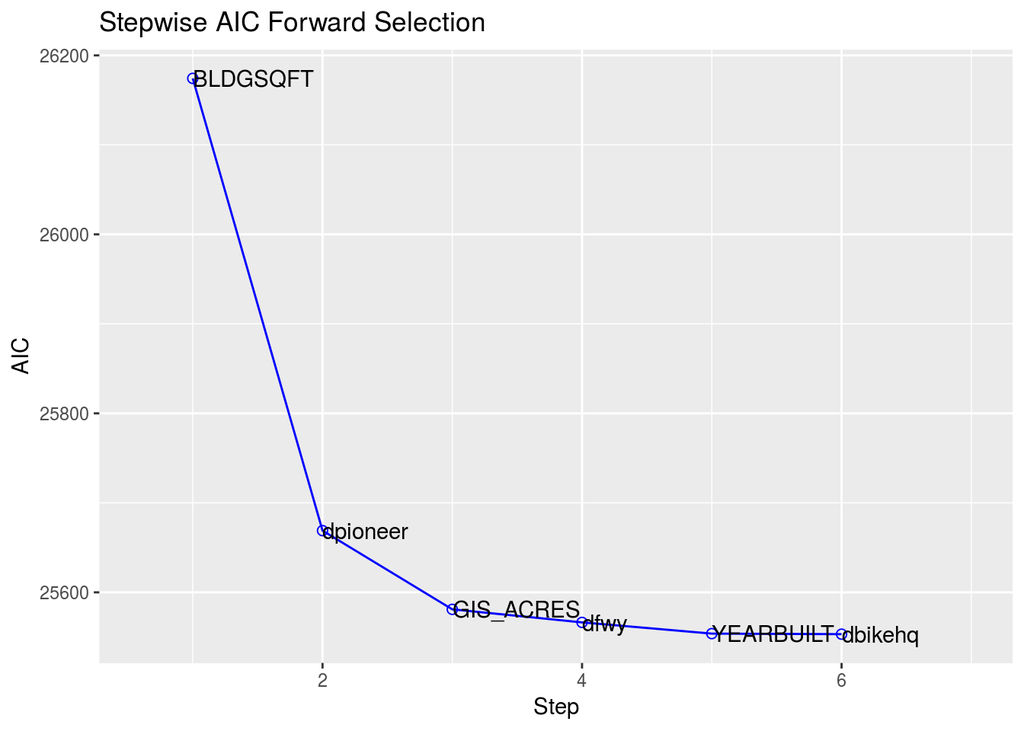

```r
plot(sfrmodel_stepboth.aic)
```

### Cross Validation

CV assesses how the results of a model will generalize to an independent data set. It is mainly used in settings where the goal is prediction, and one wants to estimate how accurately a predictive model will perform in practice.

```r
if (!require(DAAG)) {
  install.packages("DAAG"); library(DAAG)
}
sfrmodel_bestsubset <- lm(TOTALVAL~BLDGSQFT+YEARBUILT+GIS_ACRES+dpioneer+dfwy, data=taxlot_sfr)

## This two lines should do a 5-fold cross-validation for the sfr model
## but there is some issue in the package
#cv_out <- cv.lm(taxlot_sfr, sfrmodel_bestsubset, seed = 29, m=5)
#cv_out["cvpred"] %>% summary

## Alternatively, use the modelr and purrr package
## This is beyond the scope of this class, provided here
## for reference
library(modelr)
library(purrr)
(taxlot_sfr_kcv <- taxlot_sfr %>%
  modelr::crossv_kfold() %>%
  mutate(model=map(train, ~lm(TOTALVAL~BLDGSQFT+YEARBUILT+GIS_ACRES+dpioneer+dfwy, data=.x)),
         rmse=map2_dbl(model, test, modelr::rmse),
         rsquare=map2_dbl(model, test, modelr::rsquare)))
```

```
## # A tibble: 5 x 6
##            train           test   .id    model      rmse   rsquare
##           <list>         <list> <chr>   <list>     <dbl>     <dbl>
## 1 <S3: resample> <S3: resample>     1 <S3: lm>  87474.80 0.7291214
## 2 <S3: resample> <S3: resample>     2 <S3: lm>  76242.86 0.8729899
## 3 <S3: resample> <S3: resample>     3 <S3: lm> 108693.02 0.6092632
## 4 <S3: resample> <S3: resample>     4 <S3: lm>  78183.12 0.9869424
## 5 <S3: resample> <S3: resample>     5 <S3: lm>  77322.38 0.7131211
```

```r
taxlot_sfr_kcv %>%
  summarise_at(c("rmse", "rsquare"), funs(mean))
```

```
## # A tibble: 1 x 2
##       rmse   rsquare
##      <dbl>     <dbl>
## 1 85583.24 0.7822876
```

## Difference-in-Difference

Load Uber DUI data

```r
######################################################
#
# Included is data on daily DUIs as recorded by the
# Seattle and San Francisco city police departments
# from July 2010 to Jun 2014.
#
# Uber operated in SF over the entire period and
# launched in Seattle on eventdate 391 (08/11/2011)
# in the data set. Data are ordered by day for each city.
#
# variables
# ---------
# eventdate : starts at 0; increases by 1 each day
# incidents : number of daily DUIs recorded
# post : dummy variable equal to 1 if date after Uber Seattle launch
# sea : dummy equal to 1 if seattle
# sf : dummy equal to 1 if San Francisco
# dayofweek : Sun-Sat, factor
# marijuana : marijuana legal (eventdate 876 ())
#

require(tidyverse)
if (!require(lubridate)) {
  install.packages("lubridate"); library(lubridate)
}

df_raw <- read_csv("data/uber_dui.csv", na=c("#N/A"))
summary(df_raw) # 493 days had no incident data;
```

```
##    eventdate        incidents           post            sea            sf       dayofweek           marijuana        month                year            mo
##  Min.   :   0.0   Min.   : 1.000   Min.   :0.000   Min.   :0.0   Min.   :0.0   Length:2844        Min.   :0.000   Length:2844        Min.   :2010   Min.   : 1.000
##  1st Qu.: 355.0   1st Qu.: 2.000   1st Qu.:0.000   1st Qu.:0.0   1st Qu.:0.0   Class :character   1st Qu.:0.000   Class :character   1st Qu.:2011   1st Qu.: 3.000
##  Median : 710.5   Median : 3.000   Median :1.000   Median :0.5   Median :0.5   Mode  :character   Median :0.000   Mode  :character   Median :2012   Median : 7.000
##  Mean   : 710.5   Mean   : 4.535   Mean   :0.725   Mean   :0.5   Mean   :0.5                      Mean   :0.192                      Mean   :2012   Mean   : 6.525
##  3rd Qu.:1066.0   3rd Qu.: 7.000   3rd Qu.:1.000   3rd Qu.:1.0   3rd Qu.:1.0                      3rd Qu.:0.000                      3rd Qu.:2013   3rd Qu.:10.000
##  Max.   :1421.0   Max.   :23.000   Max.   :1.000   Max.   :1.0   Max.   :1.0                      Max.   :1.000                      Max.   :2014   Max.   :12.000
##                   NA's   :493
```

```r
# For SFPD, only days w/ incidents reported;
# Not sure about Seattle PD

# To make things simpler, let's just assume all missing
# days had no DUI arrests in either city
df <- df_raw %>%
  transmute(eventdate,
            date=as_date("2010-7-16") + eventdate,
            dayofweek,
            city=ifelse(sea==1, "Seattle", "SF"),
            incidents=ifelse(is.na(incidents), 0, incidents),
            post,
            marijuana
         )

summary(df)
```

```
##    eventdate           date             dayofweek             city             incidents           post         marijuana
##  Min.   :   0.0   Min.   :2010-07-16   Length:2844        Length:2844        Min.   : 0.000   Min.   :0.000   Min.   :0.000
##  1st Qu.: 355.0   1st Qu.:2011-07-06   Class :character   Class :character   1st Qu.: 1.000   1st Qu.:0.000   1st Qu.:0.000
##  Median : 710.5   Median :2012-06-25   Mode  :character   Mode  :character   Median : 2.000   Median :1.000   Median :0.000
##  Mean   : 710.5   Mean   :2012-06-25                                         Mean   : 3.749   Mean   :0.725   Mean   :0.192
##  3rd Qu.:1066.0   3rd Qu.:2013-06-16                                         3rd Qu.: 6.000   3rd Qu.:1.000   3rd Qu.:0.000
##  Max.   :1421.0   Max.   :2014-06-06                                         Max.   :23.000   Max.   :1.000   Max.   :1.000
```

### Visualization

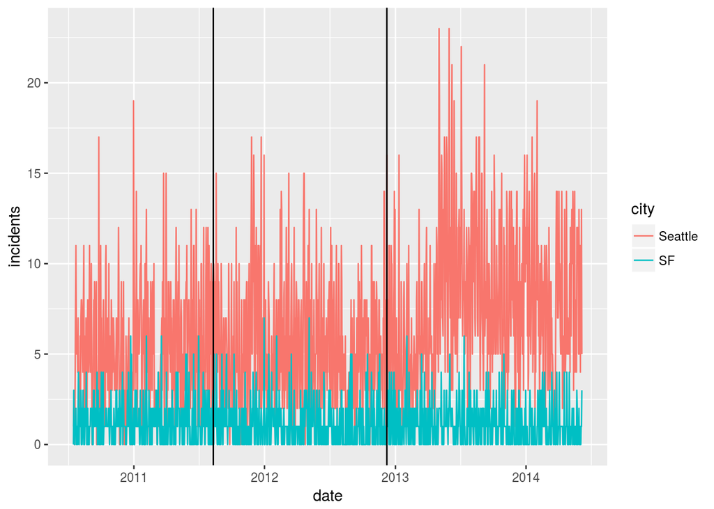

```r
library(ggplot2)

ggplot(df, aes(x=date, y=incidents, color=city)) +
  geom_line() +
  geom_vline(xintercept = as_date("2011-08-11")) +
  geom_vline(xintercept = as_date("2012-12-08"))
```

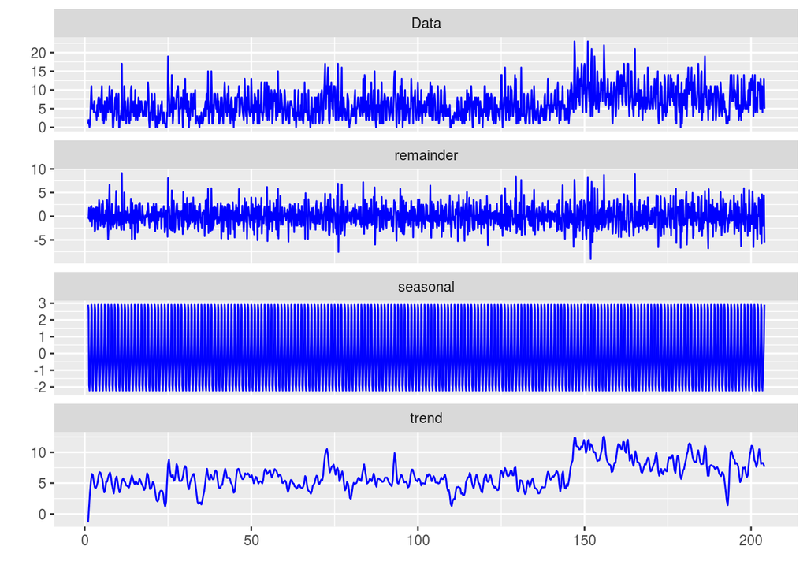

```r
df_sea <- df %>% filter(city=="Seattle")

if (!require(ggfortify)) {
  install.packages("ggfortify"); library(ggfortify)
}

# Visually inspect the weekly pattern
sea_ts <- ts(df_sea$incidents, frequency = 7)
autoplot(stl(sea_ts, s.window = 'periodic'), ts.colour = 'blue')
```

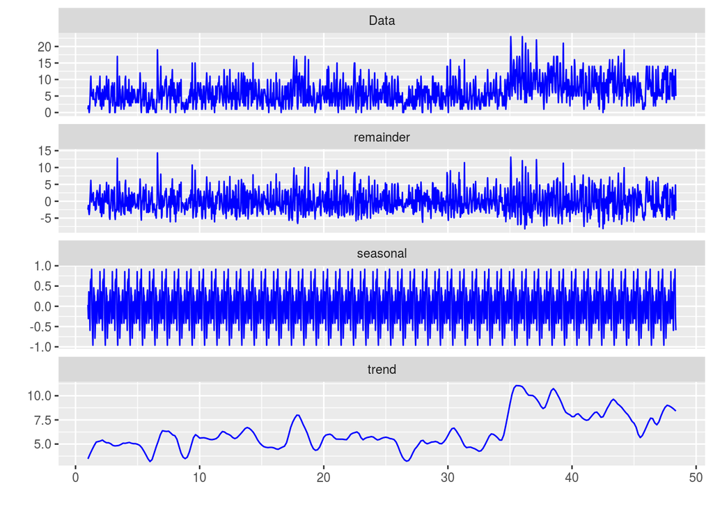

```r
# Visually inspect the monthly pattern
sea_ts <- ts(df_sea$incidents, frequency = 30)
autoplot(stl(sea_ts, s.window = 'periodic'), ts.colour = 'blue')
```

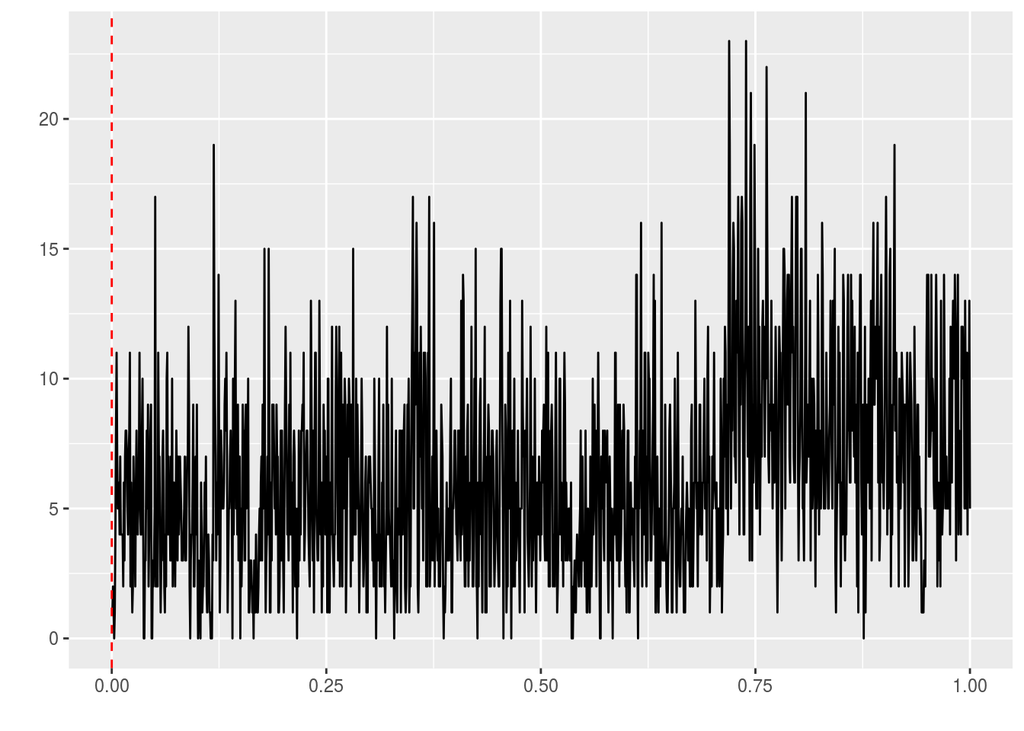

```r
if (!require(strucchange)) {
  install.packages("strucchange"); library(strucchange)
}

autoplot(breakpoints(incidents ~ eventdate, data=df_sea))
```